# meta-CART TRACE

Milou Sep

4/9/2021

# fix missing values

are there missing values?

```r
is.na(data.explore) %>% any()
```

```
## [1] TRUE
```

are there variables with > 1/3 missing?

```r
which(colSums(is.na(data.explore)) > (1/3)*nrow(data.explore)) # no values with 1/3 missing
```

```
## named integer(0)
```

check variable types

```r
str(data.explore) # all correct
```

```
## Classes 'escalc' and 'data.frame':   1647 obs. of  18 variables:
##  $ subject     : Factor w/ 7 levels "Mixed","Military",..: 3 3 3 3 3 3 3 3 3 3 ...
##  $ sex.PTSD    : Factor w/ 3 levels "F","M","MF": 2 2 2 2 2 2 2 2 2 2 ...
##  $ control.type: Factor w/ 3 levels "ShamExp","TraumaExp",..: 2 2 2 2 3 3 3 3 3 3 ...
##  $ ptsd.type2  : Factor w/ 16 levels "Accident","Assault",..: 4 4 4 4 4 4 4 4 4 4 ...
##  $ population2 : Factor w/ 16 levels "Albino Swiss (CD1)",..: 15 15 15 15 15 15 15 15 15 15 ...
##  $ measure2    : Factor w/ 5 levels "exploration",..: 4 4 4 4 4 4 4 4 4 4 ...
##  $ time.pseudo : num  30 30 30 30 NA NA NA NA NA NA ...
##  $ rhythm      : Factor w/ 3 levels "active","inactive",..: 1 1 1 1 1 1 1 1 1 1 ...
##  $ comparison  : Factor w/ 6 levels "A","B","C","D",..: 3 3 3 3 1 1 1 1 1 1 ...
##  $ new.idPTSD  : Factor w/ 408 levels "10066999.13",..: 398 398 398 398 400 400 400 400 400 400 ...
##  $ age.PTSD.cat: Factor w/ 4 levels "(mature) adult",..: 2 2 2 2 2 2 2 2 2 2 ...
##  $ subject.cat : Factor w/ 2 levels "Animal","Human": 2 2 2 2 2 2 2 2 2 2 ...
##  $ type        : Factor w/ 10 levels "autobio","olfactory",..: 1 1 1 1 6 6 6 6 6 6 ...
##  $ phase       : Factor w/ 3 levels "E","L","M": 3 3 3 3 2 2 3 3 2 2 ...
##  $ valence     : Factor w/ 4 levels "E","F","N","T": 1 1 1 1 3 3 3 3 3 3 ...
##  $ cuectx      : Factor w/ 5 levels "context","cue",..: 2 2 2 2 2 2 2 2 2 2 ...
##  $ yi          : num  -2 -4.56 0 -3.04 -0.36 ...
##   ..- attr(*, "ni")= num [1:18] 32 32 32 24 32 24 24 39 43 32 ...
##   ..- attr(*, "measure")= chr "SMD"
##  $ vi          : num  0.192 0.455 0.13 0.274 0.135 ...
##  - attr(*, "yi.names")= chr "yi"
##  - attr(*, "vi.names")= chr "vi"
##  - attr(*, "digits")= Named num [1:9] 4 4 4 4 4 4 4 4 4
##   ..- attr(*, "names")= chr [1:9] "est" "se" "test" "pval" ...
```

```r
#check missing values
summary(data.frame(data.explore)) # in sex and time pseudo
```

```
##              subject    sex.PTSD       control.type      ptsd.type2
##  Mixed           : 55   F   :  96   ShamExp  :407   SPS       :462
##  Military        : 10   M   :1220   TraumaExp:395   FS        :299
##  Veteran         :216   MF  : 324   UnExp    :845   Deployment:266
##  Military+Veteran:  4   NA's:   7                   Mixed     :227
##  Civilian        :273                               PSS       :124
##  Rat             :915                               RS        : 86
##  Mice            :174                               (Other)   :183
##          population2            measure2    time.pseudo           rhythm
##  Sprague-Dawley:680   exploration   :449   Min.   : 0.2500   active  :737
##  Civilian      :280   freezing      :634   1st Qu.: 0.8475   inactive:569
##  Veterans      :278   manipulation  :  6   Median : 2.1186   unknown :341
##  Wistar        :160   non-physiology:393   Mean   : 6.3510
##  C57BL/6       :137   physiology    :165   3rd Qu.: 5.0000
##  Lewis         : 30                        Max.   :55.0000
##  (Other)       : 82                        NA's   :139
##  comparison        new.idPTSD           age.PTSD.cat  subject.cat
##  A:237      12460691.54 :  26   (mature) adult: 223   Animal:1089
##  B:  5      12644351.355:  25   middle-aged   : 295   Human : 558
##  C:316      27686278.13 :  24   old adult     : 110
##  D:963      32302820.1  :  24   young adult   :1019
##  E: 47      15967648.52 :  18
##  F: 79      18313695.20 :  18
##             (Other)     :1512
##       type     phase   valence        cuectx          yi
##  threat :937   E:422   E: 49   context   :701   Min.   :-29.0425
##  verbal :236   L:400   F:665   cue       :909   1st Qu.: -0.9564
##  spatial:223   M:825   N:574   cuecontext:  4   Median : -0.2607
##  visual : 96           T:359   cuectx    : 15   Mean   : -0.1745
##  safety : 81                   cuecue    : 18   3rd Qu.:  0.5320
##  autobio: 39                                    Max.   : 30.1581
##  (Other): 35
##        vi
##  Min.   : 0.008073
##  1st Qu.: 0.122452
##  Median : 0.210303
##  Mean   : 0.409207
##  3rd Qu.: 0.357592
##  Max.   :28.672211
##
```

```r
factors.to.fix <- c("sex.PTSD"#, "sex.HC"
)
numeric.to.fix <- c("time.pseudo")

for (i in c(1:length(numeric.to.fix))) {
  # i=1
  numeric.to.fix[[i]] -> varname
  data.explore[is.na(data.explore[,varname]),varname] <- median(unlist(data.explore[,varname]), na.rm = T)
}

#categorical missing: substitute with most common category  {from mAP}
categorical_mode <- function(x){
  names(table(x))[which.max(table(x))]
}


for (i in c(1:length(factors.to.fix))) {
  # i=1
  factors.to.fix[[i]] -> varname
  data.explore[is.na(data.explore[,varname]),varname] <- categorical_mode(unlist(data.explore[,varname]))
}

#any missing values left?
summary(data.frame(data.explore))
```

```
##              subject    sex.PTSD     control.type      ptsd.type2
##  Mixed           : 55   F :  96   ShamExp  :407   SPS       :462
##  Military        : 10   M :1227   TraumaExp:395   FS        :299
##  Veteran         :216   MF: 324   UnExp    :845   Deployment:266
##  Military+Veteran:  4                             Mixed     :227
##  Civilian        :273                             PSS       :124
##  Rat             :915                             RS        : 86
##  Mice            :174                             (Other)   :183
##          population2            measure2    time.pseudo           rhythm
##  Sprague-Dawley:680   exploration   :449   Min.   : 0.2500   active  :737
##  Civilian      :280   freezing      :634   1st Qu.: 0.8475   inactive:569
##  Veterans      :278   manipulation  :  6   Median : 2.1186   unknown :341
##  Wistar        :160   non-physiology:393   Mean   : 5.9939
##  C57BL/6       :137   physiology    :165   3rd Qu.: 4.2308
##  Lewis         : 30                        Max.   :55.0000
##  (Other)       : 82
##  comparison        new.idPTSD           age.PTSD.cat  subject.cat
##  A:237      12460691.54 :  26   (mature) adult: 223   Animal:1089
##  B:  5      12644351.355:  25   middle-aged   : 295   Human : 558
##  C:316      27686278.13 :  24   old adult     : 110
##  D:963      32302820.1  :  24   young adult   :1019
##  E: 47      15967648.52 :  18
##  F: 79      18313695.20 :  18
##             (Other)     :1512
##       type     phase   valence        cuectx          yi
##  threat :937   E:422   E: 49   context   :701   Min.   :-29.0425
##  verbal :236   L:400   F:665   cue       :909   1st Qu.: -0.9564
##  spatial:223   M:825   N:574   cuecontext:  4   Median : -0.2607
##  visual : 96           T:359   cuectx    : 15   Mean   : -0.1745
##  safety : 81                   cuecue    : 18   3rd Qu.:  0.5320
##  autobio: 39                                    Max.   : 30.1581
##  (Other): 35
##        vi
##  Min.   : 0.008073
##  1st Qu.: 0.122452
##  Median : 0.210303
##  Mean   : 0.409207
##  3rd Qu.: 0.357592
##  Max.   :28.672211
##
```

```r
any(is.na(data.explore)) # no
```

```
## [1] FALSE
```

## split data

Comparison B [B=non-exposed vs trauma exposed no PTSD (human)] is excluded from clinical data, as the experimental group does not contain PTSD patients. Note, this comparison is used in the sensitivity analysis of the theorydriven analysis. The comparison variable is also excluded from the human dataset, as the difference between comparison A [A= non-exposed vs trauma-exposed PTSD (human)] and comparison C [C=trauma-exposed (noPTSD) vs trauma-exposed PTSD (human)] is captured by the ‘control type’ variable (with levels unexposed, shamexposed, trauma exposed).

[A= non-exposed vs trauma-exposed PTSD (human); B=non-exposed vs trauma exposed no PTSD (human); C=trauma-exposed (noPTSD) vs trauma-exposed PTSD (human); D=non-exposed vs trauma-exposed (no PTSD checked) (animal); E=non-exposed vs trauma-exposed PTSD (animal); F=trauma-exposed (no ptsd) vs trauma-exposed PTSD (animal)]

```r
data.explore %>%
  filter(subject.cat == "Human") %>%
  filter(comparison != "B") %>%
  select(-c(rhythm, subject.cat, comparison)) %>%
  droplevels() ->clinical
str(clinical)
```

```
## Classes 'escalc' and 'data.frame':   553 obs. of  15 variables:
##  $ subject     : Factor w/ 5 levels "Mixed","Military",..: 3 3 3 3 3 3 3 3 3 3 ...
##  $ sex.PTSD    : Factor w/ 3 levels "F","M","MF": 2 2 2 2 2 2 2 2 2 2 ...
##  $ control.type: Factor w/ 2 levels "TraumaExp","UnExp": 1 1 1 1 2 2 2 2 2 2 ...
##  $ ptsd.type2  : Factor w/ 10 levels "Accident","Assault",..: 4 4 4 4 4 4 4 4 4 4 ...
##  $ population2 : Factor w/ 2 levels "Civilian","Veterans": 2 2 2 2 2 2 2 2 2 2 ...
##  $ measure2    : Factor w/ 2 levels "non-physiology",..: 1 1 1 1 1 1 1 1 1 1 ...
##  $ time.pseudo : num  30 30 30 30 2.12 ...
##  $ new.idPTSD  : Factor w/ 97 levels "10066999.13",..: 90 90 90 90 92 92 92 92 92 92 ...
##  $ age.PTSD.cat: Factor w/ 3 levels "(mature) adult",..: 2 2 2 2 2 2 2 2 2 2 ...
##  $ type        : Factor w/ 9 levels "autobio","safety",..: 1 1 1 1 5 5 5 5 5 5 ...
##  $ phase       : Factor w/ 3 levels "E","L","M": 3 3 3 3 2 2 3 3 2 2 ...
##  $ valence     : Factor w/ 4 levels "E","F","N","T": 1 1 1 1 3 3 3 3 3 3 ...
##  $ cuectx      : Factor w/ 4 levels "context","cue",..: 2 2 2 2 2 2 2 2 2 2 ...
##  $ yi          : num  -2 -4.56 0 -3.04 -0.36 ...
##   ..- attr(*, "ni")= num [1:15] 32 32 32 24 32 24 24 32 24 43 ...
##   ..- attr(*, "measure")= chr "SMD"
##  $ vi          : num  0.192 0.455 0.13 0.274 0.135 ...
##  - attr(*, "yi.names")= chr "yi"
##  - attr(*, "vi.names")= chr "vi"
##  - attr(*, "digits")= Named num [1:9] 4 4 4 4 4 4 4 4 4
##   ..- attr(*, "names")= chr [1:9] "est" "se" "test" "pval" ...
```

Comparison is included in the preclinical dataset, as most datapoints come from comparison D and we want to explore the influence of this experimental variation.

```r
data.explore %>%
  filter(subject.cat == "Animal") %>%
  select(-subject.cat) %>%
  droplevels() ->preclinical
str(preclinical)
```

```
## Classes 'escalc' and 'data.frame':   1089 obs. of  17 variables:
##  $ subject     : Factor w/ 2 levels "Rat","Mice": 1 1 1 1 1 1 1 1 2 2 ...
##  $ sex.PTSD    : Factor w/ 3 levels "F","M","MF": 2 2 2 2 2 2 2 2 2 2 ...
##  $ control.type: Factor w/ 3 levels "ShamExp","TraumaExp",..: 1 1 1 1 1 1 1 3 1 1 ...
##  $ ptsd.type2  : Factor w/ 7 levels "FS","Mixed","PSS",..: 7 7 7 1 1 1 1 6 1 1 ...
##  $ population2 : Factor w/ 14 levels "Albino Swiss (CD1)",..: 12 12 12 14 14 14 14 12 3 3 ...
##  $ measure2    : Factor w/ 3 levels "exploration",..: 1 1 1 1 1 1 1 2 2 2 ...
##  $ time.pseudo : num  1.78 1.78 1.78 1.19 1.19 ...
##  $ rhythm      : Factor w/ 3 levels "active","inactive",..: 2 2 2 2 2 2 2 2 1 1 ...
##  $ comparison  : Factor w/ 3 levels "D","E","F": 1 1 1 1 1 1 1 1 1 1 ...
##  $ new.idPTSD  : Factor w/ 309 levels "12644351.355",..: 308 307 309 3 3 3 3 6 12 12 ...
##  $ age.PTSD.cat: Factor w/ 2 levels "(mature) adult",..: 2 2 2 2 2 2 2 2 2 2 ...
##  $ type        : Factor w/ 5 levels "olfactory","safety",..: 3 3 3 4 4 4 4 4 4 4 ...
##  $ phase       : Factor w/ 3 levels "E","L","M": 3 3 3 3 3 3 3 3 3 3 ...
##  $ valence     : Factor w/ 3 levels "F","N","T": 2 3 3 3 3 3 3 1 3 3 ...
##  $ cuectx      : Factor w/ 4 levels "context","cue",..: 1 1 1 1 1 1 1 1 1 1 ...
##  $ yi          : num  -0.276 -1.693 -2.454 1.406 -1.093 ...
##   ..- attr(*, "ni")= num [1:17] 32 32 32 24 32 24 24 39 43 32 ...
##   ..- attr(*, "measure")= chr "SMD"
##  $ vi          : num  0.252 0.33 0.584 0.119 0.109 ...
##  - attr(*, "yi.names")= chr "yi"
##  - attr(*, "vi.names")= chr "vi"
##  - attr(*, "digits")= Named num [1:9] 4 4 4 4 4 4 4 4 4
##   ..- attr(*, "names")= chr [1:9] "est" "se" "test" "pval" ...
```

# metaCART: tree-model

- strength of the package metacart is that it can easily explore the interaction effects among multiple moderators using an interpretable tree model.
- multi-categorical variables, it creates automatically the contrasts between (combinations of) categories that account for the highest amount of heterogeneity.

from: 1. Li X, Dusseldorp E, Su X, Meulman JJ. Multiple moderator meta-analysis using the R-package Meta-CART. Behav Res Methods [Internet]. 2020;52(6):2657–73. Available from: http://dx.doi.org/10.3758/s13428-020-01360-0

- RE model
- c=0.5
- first fit without lookahead -> then recommended to use lookahead = T (especially in REmrt)
- maxL 10? geen advies, zelfde als hier: [1. Li X, Dusseldorp E, Su X, Meulman JJ. Multiple moderator meta-analysis using the R-package Meta-CART. Behav Res Methods. 2020;52(6):2657-2673. doi:10.3758/s13428-020-01360-0] ) ## Clinical

```r
readRDS( "processed_data/REtree.C.rds")->REtree.C
```

inspect warnings

```r
REtree.C$initial.tree
```

```
##            Qb      tau2
## 1    0.000000 1.1428857
## 2    5.636903 1.1455383
## 3  237.681512 0.7869333
## 4  276.986516 0.7611391
## 5  296.528711 0.7438629
## 6  312.413679 0.7302100
## 7  328.339308 0.7208354
## 8  343.703763 0.7094398
## 9  355.762821 0.7032998
## 10 366.585934 0.6999681
## 11 379.382039 0.6965316
##                                                                          split
## 1                                                                         <NA>
## 2                                                   age.PTSD.cat = middle-aged
```

[output cut: 21 more lines]

NB eerste split is NA (ongeacht lookahead true or false), is hier ook: 1. Li X, Dusseldorp E, Su X, Meulman JJ. Multiple moderator meta-analysis using the R-package Meta-CART. Behav Res Methods. 2020;52(6):2657-2673. doi:10.3758/s13428-020-01360-0

```r
summary(REtree.C)
```

```
##
## Random Effects meta-tree (K = 553 studies);
## REmrt(formula = formula(c.vars.form), data = clinical, vi = vi,
##     c = 0.5, maxL = 10, xval = 10, lookahead = T)
##
## A tree with 7 terminal nodes was detected
## Moderators were detected as: age.PTSD.cat, subject, type, ptsd.type2
##
## Test for Between-Subgroups Heterogeneity under RE assumption:
## Qb = 328.339 (df = 6), p-value < 1e-04;
## The estimate for the residual heterogeneity tau2 = 0.721;
##
## Subgroup Meta-analysis Results:
##      K      g    se    zval  pval  ci.lb  ci.ub
## 4    6 -5.991 0.359 -16.693 0.000 -6.695 -5.288 ***
## 6   36 -1.443 0.153  -9.418 0.000 -1.744 -1.143 ***
## 9   56 -0.090 0.122  -0.736 0.462 -0.329  0.149
## 10 219 -0.326 0.062  -5.270 0.000 -0.447 -0.205 ***
## 11  35  0.247 0.160   1.546 0.122 -0.066  0.561
## 12 167 -0.714 0.071 -10.106 0.000 -0.853 -0.576 ***
## 13  34 -0.116 0.155  -0.748 0.454 -0.419  0.187
## ---
## Signif. codes:  0 '***' 0.001 '**' 0.01 '*' 0.05 '.' 0.1 ' ' 1
```

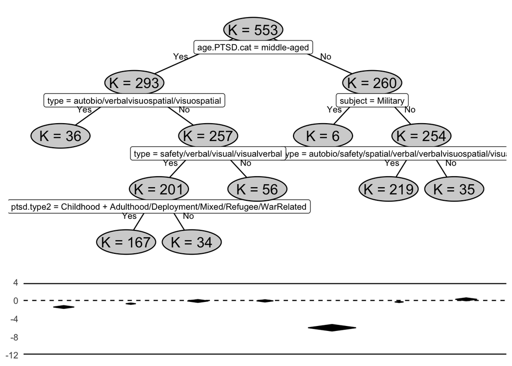

```r
plot(REtree.C)
```

```r
jpeg(file="results/metaCART.clinical.lookaheadT.jpeg", height =3000, width = 2000, res=300, pointsize = 12)
plot(REtree.C)
dev.off()
```

## Preclinical

```r
readRDS("processed_data/REtree.P.rds")->REtree.P
```

inspect warnings

```r
REtree.P$initial.tree  # eerste split is NA
```

```
##           Qb      tau2
## 1     0.0000 1.8413828
## 2   291.7207 1.6081842
## 3  1290.0757 1.0477482
## 4  1483.8523 0.9772386
## 5  1563.8766 0.9520598
## 6  1658.6126 0.9166304
## 7  1791.8971 0.8890003
## 8  1872.7135 0.8592187
## 9  1960.2207 0.8248167
## 10 2029.6488 0.8019685
## 11 2093.6152 0.7900508
##                                                         split          mod
## 1                                                        <NA>         <NA>
## 2                      type = spatial/safety/visual/olfactory         type
```

[output cut: 21 more lines]

```r
summary(REtree.P)
```

```
##
## Random Effects meta-tree (K = 1089 studies);
## REmrt(formula = formula(p.vars.form), data = preclinical, vi = vi,
##     c = 0.5, maxL = 10, xval = 10, lookahead = T)
##
## A tree with 8 terminal nodes was detected
## Moderators were detected as: type, phase, ptsd.type2, rhythm, population2
##
## Test for Between-Subgroups Heterogeneity under RE assumption:
## Qb = 1872.713 (df = 7), p-value < 1e-04;
## The estimate for the residual heterogeneity tau2 = 0.859;
##
## Subgroup Meta-analysis Results:
##      K      g    se    zval  pval  ci.lb  ci.ub
## 4  341 -1.127 0.060 -18.829 0.000 -1.244 -1.010 ***
## 6  244  0.776 0.069  11.317 0.000  0.641  0.910 ***
## 9   61 -0.376 0.127  -2.950 0.003 -0.625 -0.126  **
## 11  90 -0.976 0.111  -8.755 0.000 -1.194 -0.757 ***
## 12  33 -4.519 0.245 -18.410 0.000 -5.000 -4.038 ***
## 13  60 -1.570 0.143 -10.970 0.000 -1.851 -1.290 ***
## 14  85  1.331 0.117  11.376 0.000  1.101  1.560 ***
## 15 175  2.377 0.089  26.759 0.000  2.203  2.551 ***
## ---
## Signif. codes:  0 '***' 0.001 '**' 0.01 '*' 0.05 '.' 0.1 ' ' 1
```

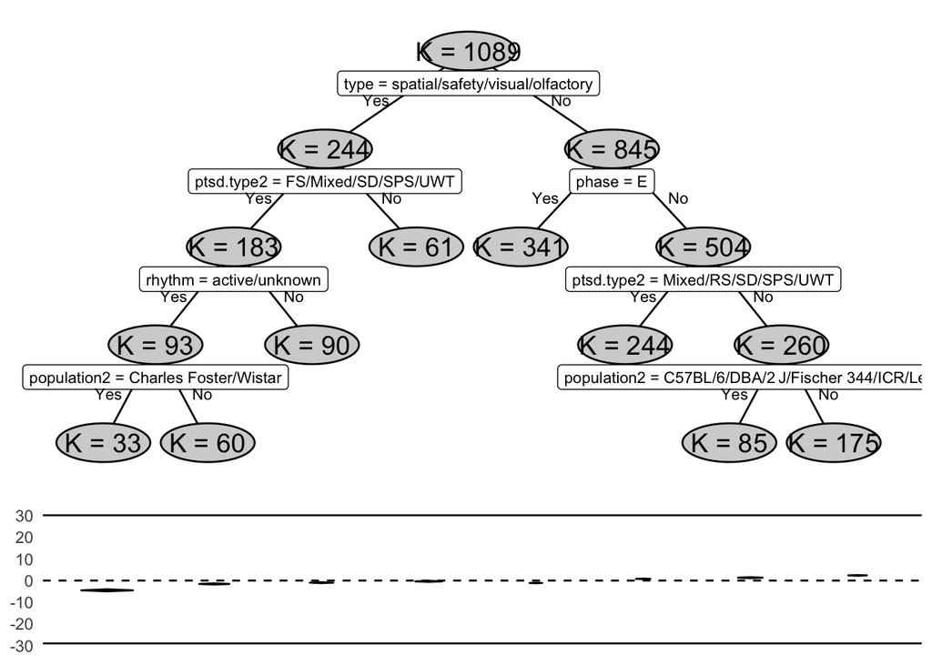

```r
plot(REtree.P)
```

```r
jpeg(file="results/metaCART.preclinical.lookaheadT.jpeg", height = 3000, width = 2000, res=300, pointsize = 12)
plot(REtree.P)
dev.off()
```

```r
# new.data<-data.frame( ) # create 1 row with values van de variableen waarvor je wil weten wat het effect is.
# predict(REtree.P)
```

# metaForest: random forest (= multiple trees)

```r
ModelInfo_mf()$notes # method from metaforest
```

[output not shown]

## Clinical

```r
readRDS(file="processed_data/fitted.clinicalMetaForest.RDS")->cv.mf.cluster.clinical
```

### Tuning parameters

```r
cv.mf.cluster.clinical
```

```
## MetaForest
##
## 553 samples
##  14 predictor
##
## No pre-processing
## Resampling: Cross-Validated (10 fold)
## Summary of sample sizes: 494, 532, 468, 511, 533, 498, ...
## Resampling results across tuning parameters:
##
##   whichweights  mtry  min.node.size  RMSE      Rsquared    MAE
##   random        2     2              1.104855  0.07823196  0.7289862
##   random        2     4              1.101210  0.08192931  0.7235365
##   random        2     6              1.135377  0.06352692  0.7398568
##   random        4     2              1.164219  0.07675201  0.7719883
##   random        4     4              1.166190  0.06719477  0.7751481
##   random        4     6              1.139202  0.06423274  0.7426883
##   random        6     2              1.181601  0.06533992  0.7806284
##   random        6     4              1.142164  0.09509947  0.7511635
##   random        6     6              1.168963  0.08384459  0.7793061
##   fixed         2     2              1.085976  0.07964560  0.6995590
##   fixed         2     4              1.103374  0.08063832  0.7087683
##   fixed         2     6              1.080513  0.07801028  0.6967844
##   fixed         4     2              1.153628  0.07857453  0.7427217
##   fixed         4     4              1.144445  0.06040177  0.7340732
##   fixed         4     6              1.097305  0.05242699  0.7106631
##   fixed         6     2              1.135640  0.06883441  0.7302150
##   fixed         6     4              1.131001  0.07971364  0.7416936
##   fixed         6     6              1.161888  0.07109759  0.7539897
##   unif          2     2              1.145703  0.08131186  0.7572460
##   unif          2     4              1.137632  0.08087368  0.7426457
##   unif          2     6              1.135304  0.06635008  0.7457588
##   unif          4     2              1.143730  0.10877342  0.7415066
##   unif          4     4              1.203265  0.09758400  0.7796135
##   unif          4     6              1.116298  0.08003219  0.7394918
##   unif          6     2              1.203738  0.09507772  0.7977268
##   unif          6     4              1.215664  0.08754181  0.8150349
##   unif          6     6              1.201977  0.06858643  0.8032299
##
## RMSE was used to select the optimal model using the smallest value.
## The final values used for the model were whichweights = fixed, mtry = 2
##  and min.node.size = 6.
```

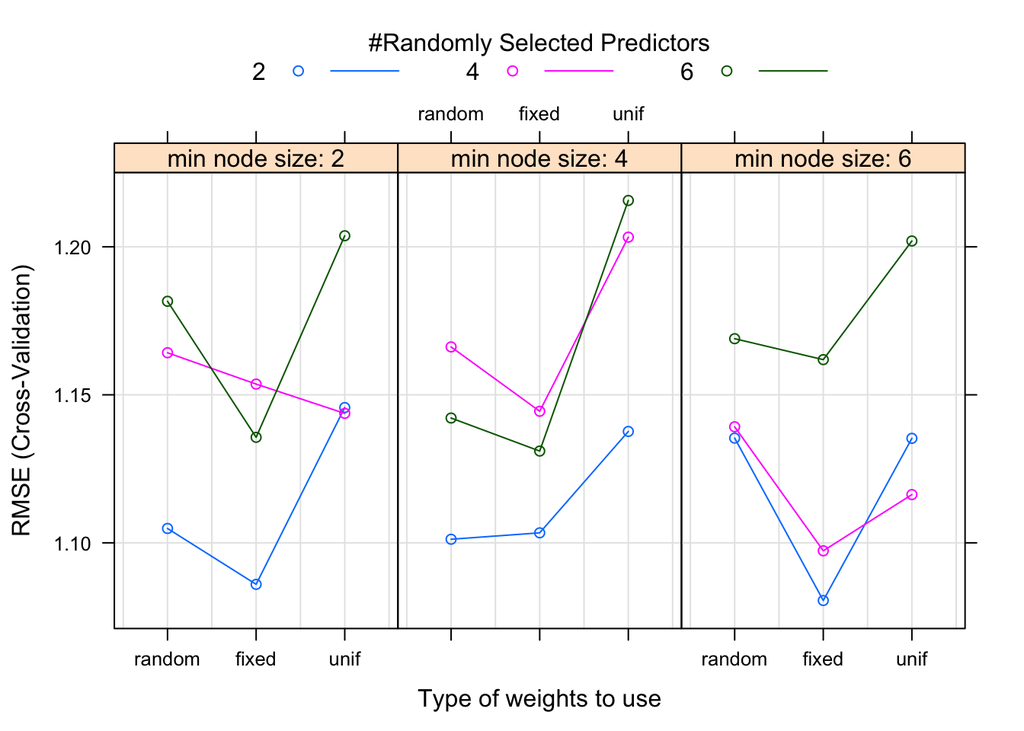

```r
plot(cv.mf.cluster.clinical) #
```

### Model convergence

```r
{
  jpeg(file="results/metaforest_Clinical_convergence.jpeg", height = 1000, width = 1000,pointsize=8, res=300) # Higher quality output
   # tiff(file="results/metaforest_Clinical_convergence.tiff", height=1000, width=1000, pointsize=8, res=300)
plot(cv.mf.cluster.clinical$finalModel)
 dev.off()
 }
```

### Model summary

```r
summary(cv.mf.cluster.clinical)
```

```
## MetaForest results
##
## Type of analysis:              Clustered MetaForest
## Number of studies:             Forest 1: 266, Forest 2: 287
## Number of moderators:          12
## Number of trees in forest:     Two forests of length 250
## Candidate variables per split: 2
## Minimum terminal node size:    6
## OOB prediction error (MSE):    1.5233
## R squared (OOB):               -0.0040
##
## Tests for Heterogeneity:
##                                tau2   tau2_SE I^2     H^2     Q-test    df
## Raw effect sizes:              1.3003 0.0853  93.4309 15.2229 7452.5461 552
## Residuals (after MetaForest):  1.2905 0.0848  93.3845 15.1160 7464.3444 552
##                                Q_p
## Raw effect sizes:              0.0000
## Residuals (after MetaForest):  0.0000
##
##
## Random intercept meta-analyses:
##                                Intercept se     ci.lb   ci.ub   p
## Raw effect sizes:              -0.5179   0.0507 -0.6172 -0.4186 0.0000
## Residuals (after MetaForest):  -0.0032   0.0505 -0.1022 0.0957  0.9490
```

### R(oob)

https://towardsdatascience.com/what-is-out-of-bag-oob-score-in-random-forest-a7fa23d710

Note, R(oob) also shown in summary above

### Cross validated R2 with SD

```r
cv.mf.cluster.clinical$results[which(cv.mf.cluster.clinical$results$whichweights == "fixed" &
                                       cv.mf.cluster.clinical$results$mtry == 2 &
                                       cv.mf.cluster.clinical$results$min.node.size == 6),] #details with the "best" model
```

```
##    whichweights mtry min.node.size     RMSE   Rsquared       MAE   RMSESD
## 12        fixed    2             6 1.080513 0.07801028 0.6967844 0.498795
##    RsquaredSD     MAESD
## 12  0.1048479 0.2201393
```

### Variable importance

```r
tiff(file="results/metaforest_Clinical_varImportance.tiff", height=1000, width=1000, pointsize=8, res=300)
VarImpPlot(cv.mf.cluster.clinical$finalModel#, n.var = 4
           )
# +  geom_hline(yintercept=11.5) +
#   annotate(geom="text", x=0.0017, y=12.5, label="Top 50%", color="darkblue")
 dev.off()
```

negative variable importance (in metaforest) ~ just no relation to outcome http://developmentaldatascience.org/post/29-01-18_metaforest_no_effect/

### PD plots

```r
# https://www.rdocumentation.org/packages/metaforest/versions/0.1.3
varImp(cv.mf.cluster.clinical,scale = F) ->imp.scores.clinical


# export variable importance scores (ordered) to csv
imp.clinical <- as.data.frame(imp.scores.clinical$importance)
imp.clinical <- data.frame(overall = imp.clinical$Overall,
                  names   = rownames(imp.clinical))
write.csv2(imp.clinical[order(imp.clinical$overall,decreasing = T),],"results/important_variables_clinical_metaforest.csv")

# select top half most imporant variables
imp.clinical[order(imp.clinical$overall,decreasing = T),] %>%
  filter(overall >0) -> important.vars.clinical
  # slice_head(.,n=nrow(.) / 2)


important.vars.clinical$names ->variable.clinical
variable.clinical
```

```
##  [1] "type"         "subject"      "age.PTSD.cat" "population2"  "time.pseudo"
##  [6] "control.type" "phase"        "sex.PTSD"     "valence"      "measure2"
```

```r
# saveRDS(variable,"processed_data/important_variables.RDS")
```

```r
# for (i in 1:length(variable.clinical)) {
#
#   thisMod <- variable.clinical[i]
#   WeightedScatter(clinical, yi = "yi", vi = "vi", vars = thisMod, summarize = TRUE)
#   ggsave(paste0("results/clinical_metaforest_WeightedScatter_", thisMod, ".tiff"))
#
#   PartialDependence(cv.mf.cluster.clinical$finalModel, vars = thisMod)
#   ggsave(paste0("results/.clinical_metaforest_partDep_", thisMod, ".tiff"))
#
#   # a <- 1
#
# } # Plots saved in your folder
{jpeg(file="results/metaforest_PD_main_clinical.jpeg", height = 1500, width = 5000, res=300) # Higher quality output
PartialDependence(cv.mf.cluster.clinical$finalModel, vars = variable.clinical, #moderator =  "phase",
                  rawdata=F#, pi = .95
                  )
dev.off()}
```

```r
{jpeg(file="results/metaforest_PD_byPhase_clinical.jpeg", height = 1500, width = 5000, res=300) # Higher quality output
PartialDependence(cv.mf.cluster.clinical$finalModel, vars = variable.clinical, moderator =  "phase",rawdata=F#, pi = .95
                  )
dev.off()}
```

```r
{jpeg(file="results/metaforest_PD_byValence_clinical.jpeg", height = 1500, width = 5000, res=300) # Higher quality output
PartialDependence(cv.mf.cluster.clinical$finalModel, vars = variable.clinical, moderator =  "valence",rawdata=F#, pi = .95
                  )
dev.off()}
```

```r
# WeightedScatter(clinical, yi = "yi", vi = "vi", vars = variable.clinical, summarize = TRUE)
```

interactions from metaCART

```r
{jpeg(file="results/metaforest_PD_clinical_metaCARTfollowup.jpeg", height = 1500, width = 6000, res=300) # Higher quality output

PartialDependence(cv.mf.cluster.clinical$finalModel, vars=c("subject", "type"), moderator = "age.PTSD.cat")
# +
#                   legend.position = c(4,2)+
#                   legend.justification=c("left, rigth")   # werkt niet.. in oic meta aanpassing op schript gemaakt
dev.off()}
```

```r
# ggarrange(
#   # PLOT.clinical
#   # #  + ylim(-7.5,3.5)  # If you want y-axis the same for clinical and preclinical
#   # # + rremove("x.text")
#   # + rremove("x.axis") + rremove("x.ticks") + rremove("xlab")
#   # + rremove("y.axis") + rremove("y.ticks"),
#
#   p,
#   # + ylim(-7.5,3.5)   # If you want y-axis the same for clinical and preclinical
#   # + rremove("x.text")
#   # + rremove("x.axis") + rremove("x.ticks") + rremove("xlab")
#   # + #rremove("ylab") +
#     # rremove("y.axis") + rremove("y.ticks"),
#   # ncol =1, nrow=2,
#   # align = "v",
#   legend="bottom",
#   common.legend = T)
```

## Preclinical

```r
readRDS(file="processed_data/fitted.preclinicalMetaForest.RDS")->cv.mf.cluster.preclinical
```

### Tuning parameters

```r
cv.mf.cluster.preclinical
```

```
## MetaForest
##
## 1089 samples
##   16 predictor
##
## No pre-processing
## Resampling: Cross-Validated (10 fold)
## Summary of sample sizes: 962, 965, 1004, 1045, 995, 958, ...
## Resampling results across tuning parameters:
##
##   whichweights  mtry  min.node.size  RMSE      Rsquared   MAE
##   random        2     2              2.348029  0.4667299  1.248851
##   random        2     4              2.345056  0.4627933  1.254557
##   random        2     6              2.359558  0.4555696  1.266601
##   random        4     2              2.216102  0.5215958  1.229585
##   random        4     4              2.240115  0.5084280  1.224436
##   random        4     6              2.233527  0.5178560  1.217817
##   random        6     2              2.197652  0.5301357  1.215354
##   random        6     4              2.223180  0.5197606  1.238420
##   random        6     6              2.237526  0.5158899  1.220234
##   fixed         2     2              2.520108  0.4337124  1.298278
##   fixed         2     4              2.523565  0.4290362  1.306403
##   fixed         2     6              2.533707  0.4288949  1.309919
##   fixed         4     2              2.379927  0.4766587  1.215109
##   fixed         4     4              2.364842  0.4832641  1.211844
##   fixed         4     6              2.413152  0.4554383  1.243399
##   fixed         6     2              2.357792  0.4717674  1.217852
##   fixed         6     4              2.358967  0.4747836  1.211493
##   fixed         6     6              2.353833  0.4802208  1.210735
##   unif          2     2              2.320901  0.4653760  1.310655
##   unif          2     4              2.306791  0.4753294  1.295814
##   unif          2     6              2.314616  0.4709422  1.284134
##   unif          4     2              2.358863  0.4784925  1.340110
##   unif          4     4              2.335965  0.4812905  1.354377
##   unif          4     6              2.277446  0.4989150  1.278783
##   unif          6     2              2.331480  0.4994248  1.367850
##   unif          6     4              2.314714  0.5048806  1.318110
##   unif          6     6              2.265192  0.5194754  1.293196
##
## RMSE was used to select the optimal model using the smallest value.
## The final values used for the model were whichweights = random, mtry = 6
##  and min.node.size = 2.
```

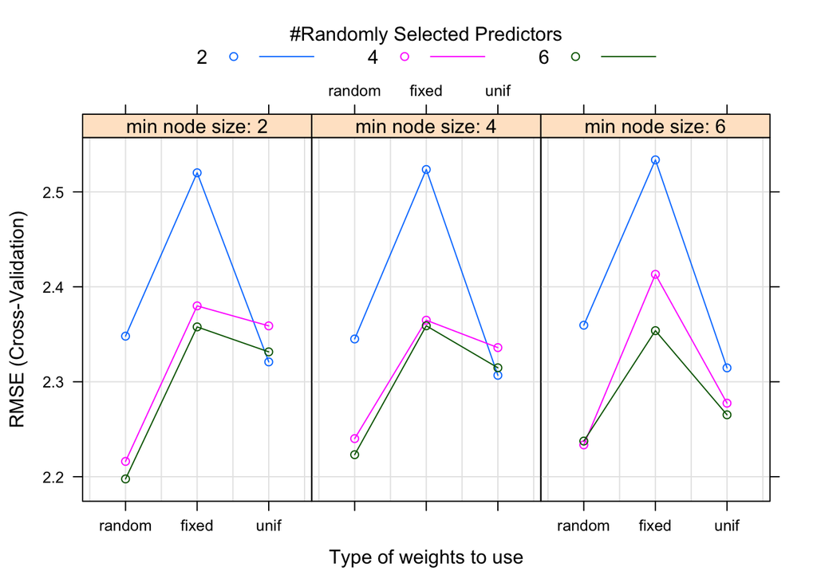

```r
plot(cv.mf.cluster.preclinical) #
```

### Model convergence

```r
 {
   #jpeg(file="results/metaforest_convergencePlot.jpeg", height = 3000, width = 3000, res=500) # Higher quality output
     jpeg(file="results/metaforest_Preclinical_convergence.jpeg", height = 1000, width = 1000,pointsize=8, res=300) # Higher quality output

plot(cv.mf.cluster.preclinical$finalModel)
 dev.off()}
```

### Model summary

```r
summary(cv.mf.cluster.preclinical)
```

```
## MetaForest results
##
## Type of analysis:              Clustered MetaForest
## Number of studies:             Forest 1: 558, Forest 2: 531
## Number of moderators:          14
## Number of trees in forest:     Two forests of length 250
## Candidate variables per split: 6
## Minimum terminal node size:    2
## OOB prediction error (MSE):    7.2962
## R squared (OOB):               0.3256
##
## Tests for Heterogeneity:
##                                tau2   tau2_SE I^2     H^2     Q-test    df
## Raw effect sizes:              4.4260 0.2070  95.0184 20.0738 9721.6222 1088
## Residuals (after MetaForest):  1.8561 0.0950  88.8875 8.9989  8246.8930 1088
##                                Q_p
## Raw effect sizes:              0.0000
## Residuals (after MetaForest):  0.0000
##
##
## Random intercept meta-analyses:
##                                Intercept se     ci.lb   ci.ub   p
## Raw effect sizes:              -0.0053   0.0667 -0.1361 0.1256  0.9372
## Residuals (after MetaForest):  -0.1333   0.0454 -0.2223 -0.0444 0.0033
```

### R(oob)

https://towardsdatascience.com/what-is-out-of-bag-oob-score-in-random-forest-a7fa23d710

Note, R(oob) also shown in summary above

### Cross validated R2 with SD

```r
cv.mf.cluster.preclinical$results[which(cv.mf.cluster.preclinical$results$whichweights == "random" &
                                          cv.mf.cluster.preclinical$results$mtry == 6 &
                                          cv.mf.cluster.preclinical$results$min.node.size == 2),] #details with the "best" model
```

```
##   whichweights mtry min.node.size     RMSE  Rsquared      MAE    RMSESD
## 7       random    6             2 2.197652 0.5301357 1.215354 0.9970165
##   RsquaredSD     MAESD
## 7  0.1066953 0.2978851
```

### Variable importance

```r
tiff(file="results/metaforest_Preclinical_varImportance.tiff", height=1000, width=1000, pointsize=8, res=300)
VarImpPlot(cv.mf.cluster.preclinical$finalModel)
# +  geom_hline(yintercept=11.5) +
#   annotate(geom="text", x=0.0017, y=12.5, label="Top 50%", color="darkblue")
 dev.off()
```

### PD plots

```r
# https://www.rdocumentation.org/packages/metaforest/versions/0.1.3
varImp(cv.mf.cluster.preclinical,scale = F) ->imp.scores.preclinical


# export variable importance scores (ordered) to csv
imp.preclinical <- as.data.frame(imp.scores.preclinical$importance)
imp.preclinical <- data.frame(overall = imp.preclinical$Overall,
                  names   = rownames(imp.preclinical))
write.csv2(imp.preclinical[order(imp.preclinical$overall,decreasing = T),],"results/important_variables_preclinical_metaforest.csv")

# select top half most imporant variables
imp.preclinical[order(imp.preclinical$overall,decreasing = T),] %>%
   filter(overall >0) -> important.vars.preclinical
   # slice_head(.,n=nrow(.) / 2)


important.vars.preclinical$names ->variable.preclinical
variable.preclinical
```

```
##  [1] "phase"        "valence"      "type"         "time.pseudo"  "control.type"
##  [6] "ptsd.type2"   "measure2"     "rhythm"       "cuectx"       "population2"
## [11] "subject"      "comparison"   "sex.PTSD"     "age.PTSD.cat"
```

```r
# saveRDS(variable,"processed_data/important_preclinical_variables.RDS")
```

```r
# for (i in 1:length(variable.clinical)) {
#
#   thisMod <- variable.clinical[i]
#   WeightedScatter(clinical, yi = "yi", vi = "vi", vars = thisMod, summarize = TRUE)
#   ggsave(paste0("results/clinical_metaforest_WeightedScatter_", thisMod, ".tiff"))
#
#   PartialDependence(cv.mf.cluster.clinical$finalModel, vars = thisMod)
#   ggsave(paste0("results/.clinical_metaforest_partDep_", thisMod, ".tiff"))
#
#   # a <- 1
#
# } # Plots saved in your folder




# } # Plots saved in your folder
{jpeg(file="results/metaforest_PD_main_preclinical.jpeg", height = 1500, width = 5000, res=300) # Higher quality output
PartialDependence(cv.mf.cluster.preclinical$finalModel, vars = variable.preclinical, #moderator =  "phase",
                  rawdata=F#, pi = .95
                  )
dev.off()}
```

```r
{jpeg(file="results/metaforest_PD_byPhase_preclinical.jpeg", height = 1500, width = 5000, res=300) # Higher quality output
PartialDependence(cv.mf.cluster.preclinical$finalModel, vars = variable.preclinical, moderator =  "phase",rawdata=F#, pi = .95
                  )
dev.off()}
```

```r
{jpeg(file="results/metaforest_PD_byValence_preclinical.jpeg", height = 1500, width = 5000, res=300) # Higher quality output
PartialDependence(cv.mf.cluster.preclinical$finalModel, vars = variable.preclinical, moderator =  "valence",rawdata=F#, pi = .95
                  )
dev.off()}
```

interactions from metaCART

```r
{jpeg(file="results/metaforest_PD_preclinical_metaCARTfollowup.jpeg", height = 1500, width = 6000, res=300) # Higher quality output

PartialDependence(cv.mf.cluster.preclinical$finalModel, vars=c("ptsd.type2", "phase"), moderator = "type")
# +
#                   legend.position = c(4,2)+
#                   legend.justification=c("left, rigth")   # werkt niet.. in oic meta aanpassing op schript gemaakt
dev.off()}
```

```r
# ggarrange(
#   # PLOT.clinical
#   # #  + ylim(-7.5,3.5)  # If you want y-axis the same for clinical and preclinical
#   # # + rremove("x.text")
#   # + rremove("x.axis") + rremove("x.ticks") + rremove("xlab")
#   # + rremove("y.axis") + rremove("y.ticks"),
#
#   p,
#   # + ylim(-7.5,3.5)   # If you want y-axis the same for clinical and preclinical
#   # + rremove("x.text")
#   # + rremove("x.axis") + rremove("x.ticks") + rremove("xlab")
#   # + #rremove("ylab") +
#     # rremove("y.axis") + rremove("y.ticks"),
#   # ncol =1, nrow=2,
#   # align = "v",
#   legend="bottom",
#   common.legend = T)
```